# STAT340 Midterm - take home portion solution pt 2

## Question 2 (pts for a-d are 2,6,1,1)

The [middle-square method](https://en.wikipedia.org/wiki/Middle-square_method) (feel free to click on this link and read the wiki page) is a very old and very crude pseudorandom generator function invented by John von Neumann in 1949. Despite its many flaws, it was much faster than other more rigorous methods at the time, so was useful in certain contexts where “perfect” randomness was not necessary.

Suppose we start with the 6-digit seed number 455455. This is our first “random” number. Next, we square this number 455455²=207,439,257,025 and we take out the middle 6 digits 439257 and this becomes out next “random” number. This process is repeated as many times as needed to get a sequence of “random” numbers.

Due to the primitive nature of this method, the sequence generated actually fails many common tests of true randomness and is therefore NOT a good way of generating random numbers. Below, we have generated a sequence of 200 numbers using this method starting from the initial seed value of 455455. Conduct a Monte Carlo test to show there is indeed strong evidence to indicate this method is NOT a good pseudorandom algorithm.

```r
middle_square = function(x) as.integer(substr(as.character(x^2),4,9))

N = 200
mc.mid = c(455455,rep(NA,N-1))

for(i in 1:(N-1)) mc.mid[i+1] = middle_square(mc.mid[i])

mc.mid
```

```
##   [1] 455455 439257 946712 263610 902321 183187 574769 359403 170516 757062
##  [11] 142871 121226 957430 672204 858217 536419 745343 536187 496498 510264
##  [21] 369349 418683 295454 930661 129896 729708 473765 453275 458225 970150
##  [31] 191022 894044 314673 190969 691589 295344 280783 390930 826264 712197
##  [41] 224566 298883 310476 953465  95506 139603 889976  57280  99840 802560
##  [51] 102553 171178  19076 893776 835538 123749 138150 854225 700350 490122
##  [61] 219574 127414 343273 836352 484667 902100 784410 299048 297063 464259
##  [71] 536419 745343 536187 496498 510264 369349 418683 295454 930661 129896
##  [81] 729708 473765 453275 458225 970150 191022 894044 314673 190969 691589
##  [91] 295344 280783 390930 826264 712197 224566 298883 310476 953465  95506
## [101] 139603 889976  57280  99840 802560 102553 171178  19076 893776 835538
## [111] 123749 138150 854225 700350 490122 219574 127414 343273 836352 484667
## [121] 902100 784410 299048 297063 464259 536419 745343 536187 496498 510264
## [131] 369349 418683 295454 930661 129896 729708 473765 453275 458225 970150
## [141] 191022 894044 314673 190969 691589 295344 280783 390930 826264 712197
## [151] 224566 298883 310476 953465  95506 139603 889976  57280  99840 802560
## [161] 102553 171178  19076 893776 835538 123749 138150 854225 700350 490122
## [171] 219574 127414 343273 836352 484667 902100 784410 299048 297063 464259
## [181] 536419 745343 536187 496498 510264 369349 418683 295454 930661 129896
## [191] 729708 473765 453275 458225 970150 191022 894044 314673 190969 691589
```

Hints:

1. Note the numbers generated using this method are always an integer with at most 6 digits (it may of course have less digits if the middle number starts with leading zeros). Therefore, you may model the generated observations under the null as being random integers sampled from 1-999,999. You can simulate this using `sample(999999,size=??,replace=??)` with the arguments `size` and `replace` set appropriately. Alternatively, you can also divide the observations by 1,000,000 and treat the resultant vector as drawn from Uniform(0,1), i.e. uniform distribution defined as $x=1$ if $0\leq x\leq1$. Or you could even divide by 100,000 and treat it as Uniform (0,10). Or something else entirely, it’s up to you.
2. As usual, generate under the null, use a summarizing statistic, and compare the simulations with your data. Make sure to think very carefully about which tail to take for your test.
3. There are MANY different statistics that will work here (I personally found 6 while writing this exam), you just need to come up with something that has high enough power to reject the null. I’ve listed some functions below that you may find useful while trying to construct a statistic. To be clear, you do NOT have to use these functions, it’s just a reference in case you want it.
   - `x%%y` computes the remainder of vector `x` when divided by `y`, e.g. `5%%2=1`
   - `floor(x)` and `ceiling(x)` can be used to round a vector `x` down or up to the nearest integer
   - `as.character(x)` and `as.numeric(x)` can convert a vector to a character or convert back to a number
   - if you want to force a numeric vector `x` to print with leading 0’s, try `sprintf(x,fmt="%06d")`
   - `strsplit(string,"")[[1]]` will let you **split a *single* input string** into a vector of the digits (note the input MUST be a single string, not a vector)
   - remember `table(x)` can be used to show a frequency table, and the output of this is just a named vector (i.e. a vector with names for each value, but you can usually ignore the names), so for example `table(c(5,5,6,7,7,7))` will give the vector `c(2,1,3)` indicating there are 2, 1, and 3 each of 5, 6, and 7.

Final hint: there are at least 3 simple descriptive summary statistics that do NOT use any of the listed functions above and can easily reject the null here. Look closely at the data in comparison to the null-generated samples and you should be able to identify them. However, a more creative (but still logically sound) solution may result in even higher power. If you either come up with a very creative (and correct) solution, or come up with a statistic that matches or beats the p-value of the best statistic I came up with, you may be awarded up to 3 bonus points at my discretion.

1. Write down a null and alternative hypothesis for this question. Use specific, technical, statistical language here (just saying “random” will NOT be sufficient, what are you specific assuming under the null?).
2. Construct a statistic, and simulate its distribution under the null. Your result should be a single vector of M numbers, where M is your number of MC iterations, and each number is the result of running your summary statistic on a null-generated sample of size 200.
3. Show a histogram with the null distribution and what you obtained in the real data set. Remember you can use `hist(x)` to quickly make a histogram of a vector `x` and `abline(v=___)` to quickly add a vertical line to the plot at $x=___$.
4. Compute the p-value of your test.

> SOLUTION

**NOTE**: `dqsample()` is just a slightly faster version of `sample()` from the `dqrng` package, you can use `sample()` instead. Also, `Table()` is a slightly faster version of `table()` from the `Rfast` package, you can just use `table()` instead.

mean, median, sd, IQR will not work. however, all of the following will work:

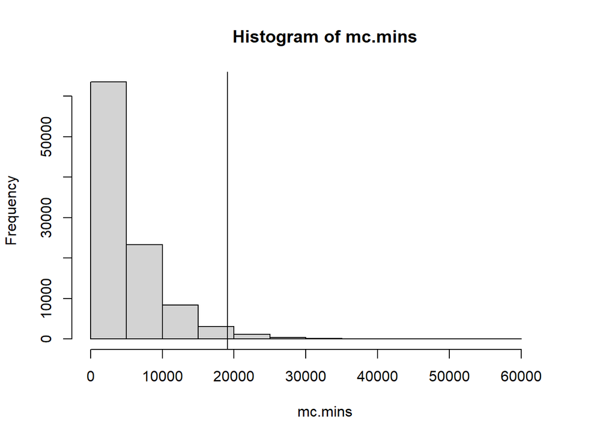

```r
# look at min
data.min = min(mc.mid)
mc.mins = replicate(1e5,min(dqsample(999999,N,replace=T)))
hist(mc.mins,xlim=c(0,max(data.min,mc.mins)*1.1)) ; abline(v=data.min)
```

```r
mean(mc.mins >= data.min)
```

```
## [1] 0.0205
```

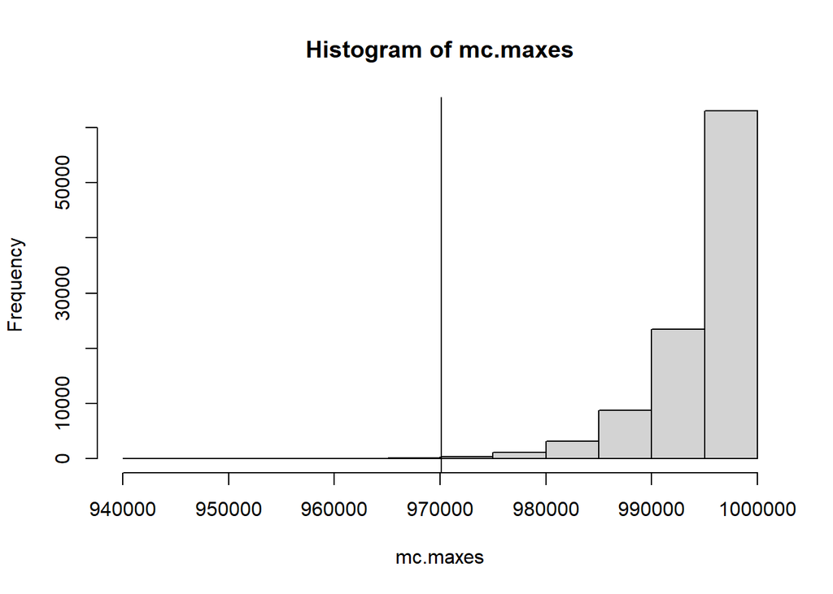

```r
# look at max
data.max = max(mc.mid)
mc.maxes = replicate(1e5,max(dqsample(999999,N,replace=T)))
hist(mc.maxes) ; abline(v=data.max)
```

```r
mean(mc.maxes <= data.max)
```

```
## [1] 0.00228
```

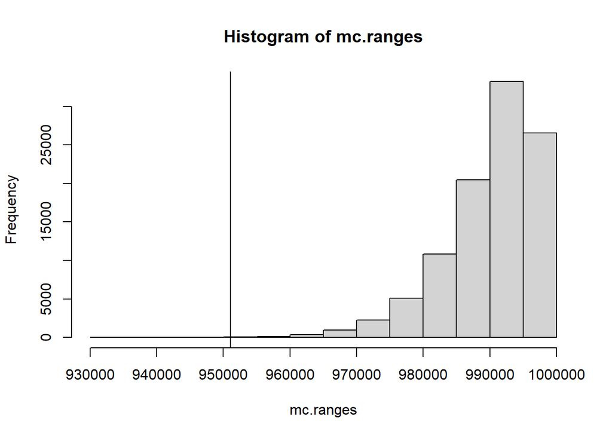

```r
# look at range
data.range = diff(range(mc.mid))
mc.ranges = replicate(1e5,diff(range(dqsample(999999,N,replace=T))))
hist(mc.ranges) ; abline(v=data.range)
```

```r
mean(mc.ranges <= data.range)
```

```
## [1] 0.00048
```